# Repaso de Clustering y Análisis de Asociación

Minería de Datos

2026-07-06

```r
knitr::opts_chunk$set(
  echo = TRUE,
  message = FALSE,
  warning = FALSE,
  fig.width = 8,
  fig.height = 5
)

# Instalar una vez si es necesario:
# install.packages(c("tidyverse", "cluster", "factoextra", "arules", "arulesViz"))

library(tidyverse)
library(cluster)
library(factoextra)
library(arules)
library(arulesViz)

set.seed(123)
```

# Objetivos del repaso

Este notebook repasa dos familias de métodos usadas en minería de datos:

1. **Clustering**: agrupar observaciones similares sin usar una variable respuesta.
2. **Análisis de asociación**: encontrar patrones frecuentes del tipo `A => B` en datos categóricos o transaccionales.
3. **Integración de ambos enfoques**: usar clustering para crear segmentos y luego reglas de asociación para describirlos e interpretarlos.

Al final del notebook se incluyen **ejercicios propuestos**.

# Parte I: Repaso de clustering

## 1. ¿Qué es clustering?

El clustering busca dividir observaciones en grupos de modo que:

- Observaciones dentro del mismo grupo sean similares entre sí.
- Observaciones de grupos diferentes sean lo más distintas posible.

No existe una variable respuesta verdadera durante el entrenamiento. Por eso, el resultado debe evaluarse con criterios internos, visualización e interpretación del dominio.

Ejemplos de uso:

- Segmentar pacientes según perfiles clínicos.
- Agrupar tumores según expresión génica.
- Identificar perfiles de clientes.
- Detectar patrones morfológicos en imágenes.
- Reducir complejidad antes de análisis posteriores.

## 2. Datos de ejemplo: iris

Usaremos el dataset `iris`, que contiene cuatro medidas morfológicas de flores y una etiqueta real llamada `Species`. En clustering **no usaremos `Species` para entrenar**, solo para evaluar la coherencia de los grupos.

```r
data(iris)

glimpse(iris)
```

```
## Rows: 150
## Columns: 5
## $ Sepal.Length <dbl> 5.1, 4.9, 4.7, 4.6, 5.0, 5.4, 4.6, 5.0, 4.4, 4.9, 5.4, 4.…
## $ Sepal.Width  <dbl> 3.5, 3.0, 3.2, 3.1, 3.6, 3.9, 3.4, 3.4, 2.9, 3.1, 3.7, 3.…
## $ Petal.Length <dbl> 1.4, 1.4, 1.3, 1.5, 1.4, 1.7, 1.4, 1.5, 1.4, 1.5, 1.5, 1.…
## $ Petal.Width  <dbl> 0.2, 0.2, 0.2, 0.2, 0.2, 0.4, 0.3, 0.2, 0.2, 0.1, 0.2, 0.…
## $ Species      <fct> setosa, setosa, setosa, setosa, setosa, setosa, setosa, s…
```

```r
summary(iris)
```

```
##   Sepal.Length    Sepal.Width     Petal.Length    Petal.Width
##  Min.   :4.300   Min.   :2.000   Min.   :1.000   Min.   :0.100
##  1st Qu.:5.100   1st Qu.:2.800   1st Qu.:1.600   1st Qu.:0.300
##  Median :5.800   Median :3.000   Median :4.350   Median :1.300
##  Mean   :5.843   Mean   :3.057   Mean   :3.758   Mean   :1.199
##  3rd Qu.:6.400   3rd Qu.:3.300   3rd Qu.:5.100   3rd Qu.:1.800
##  Max.   :7.900   Max.   :4.400   Max.   :6.900   Max.   :2.500
##        Species
##  setosa    :50
##  versicolor:50
##  virginica :50
##
##
##
```

Seleccionamos solo variables numéricas.

```r
iris_num <- iris %>%
  select(where(is.numeric))

head(iris_num)
```

|  | Sepal.Length | Sepal.Width | Petal.Length | Petal.Width |
| --- | --- | --- | --- | --- |
| 1 | 5.1 | 3.5 | 1.4 | 0.2 |
| 2 | 4.9 | 3.0 | 1.4 | 0.2 |
| 3 | 4.7 | 3.2 | 1.3 | 0.2 |
| 4 | 4.6 | 3.1 | 1.5 | 0.2 |
| 5 | 5.0 | 3.6 | 1.4 | 0.2 |
| 6 | 5.4 | 3.9 | 1.7 | 0.4 |

## 3. Estandarización

La estandarización es clave cuando las variables están en escalas diferentes. Sin estandarizar, variables con valores grandes pueden dominar la distancia.

```r
iris_scaled <- scale(iris_num)

summary(iris_scaled)
```

```
##   Sepal.Length       Sepal.Width       Petal.Length      Petal.Width
##  Min.   :-1.86378   Min.   :-2.4258   Min.   :-1.5623   Min.   :-1.4422
##  1st Qu.:-0.89767   1st Qu.:-0.5904   1st Qu.:-1.2225   1st Qu.:-1.1799
##  Median :-0.05233   Median :-0.1315   Median : 0.3354   Median : 0.1321
##  Mean   : 0.00000   Mean   : 0.0000   Mean   : 0.0000   Mean   : 0.0000
##  3rd Qu.: 0.67225   3rd Qu.: 0.5567   3rd Qu.: 0.7602   3rd Qu.: 0.7880
##  Max.   : 2.48370   Max.   : 3.0805   Max.   : 1.7799   Max.   : 1.7064
```

## 4. Distancia euclidiana

La distancia euclidiana mide qué tan separadas están dos observaciones en el espacio de variables numéricas.

```r
d_iris <- dist(iris_scaled, method = "euclidean")

as.matrix(d_iris)[1:5, 1:5]
```

```
##           1         2         3         4         5
## 1 0.0000000 1.1722914 0.8427840 1.0999999 0.2592702
## 2 1.1722914 0.0000000 0.5216255 0.4325508 1.3818560
## 3 0.8427840 0.5216255 0.0000000 0.2829432 0.9882608
## 4 1.0999999 0.4325508 0.2829432 0.0000000 1.2459861
## 5 0.2592702 1.3818560 0.9882608 1.2459861 0.0000000
```

# K-means

## 5. Ajustar K-means

K-means necesita definir previamente el número de clusters `k`. En este ejemplo usamos `k = 3` porque sabemos que `iris` tiene tres especies, pero en un análisis real deberíamos evaluar varios valores de `k`.

```r
km3 <- kmeans(iris_scaled, centers = 3, nstart = 25)

km3$centers
```

```
##   Sepal.Length Sepal.Width Petal.Length Petal.Width
## 1  -1.01119138  0.85041372   -1.3006301  -1.2507035
## 2  -0.05005221 -0.88042696    0.3465767   0.2805873
## 3   1.13217737  0.08812645    0.9928284   1.0141287
```

```r
km3$size
```

```
## [1] 50 53 47
```

Agregamos los clusters al dataset original.

```r
iris_km <- iris %>%
  mutate(cluster_kmeans = factor(km3$cluster))

head(iris_km)
```

|  | Sepal.Length | Sepal.Width | Petal.Length | Petal.Width | Species | cluster_kmeans |
| --- | --- | --- | --- | --- | --- | --- |
| 1 | 5.1 | 3.5 | 1.4 | 0.2 | setosa | 1 |
| 2 | 4.9 | 3.0 | 1.4 | 0.2 | setosa | 1 |
| 3 | 4.7 | 3.2 | 1.3 | 0.2 | setosa | 1 |
| 4 | 4.6 | 3.1 | 1.5 | 0.2 | setosa | 1 |
| 5 | 5.0 | 3.6 | 1.4 | 0.2 | setosa | 1 |
| 6 | 5.4 | 3.9 | 1.7 | 0.4 | setosa | 1 |

## 6. Visualización con PCA

PCA permite proyectar datos multivariados en dos dimensiones para visualizar los clusters.

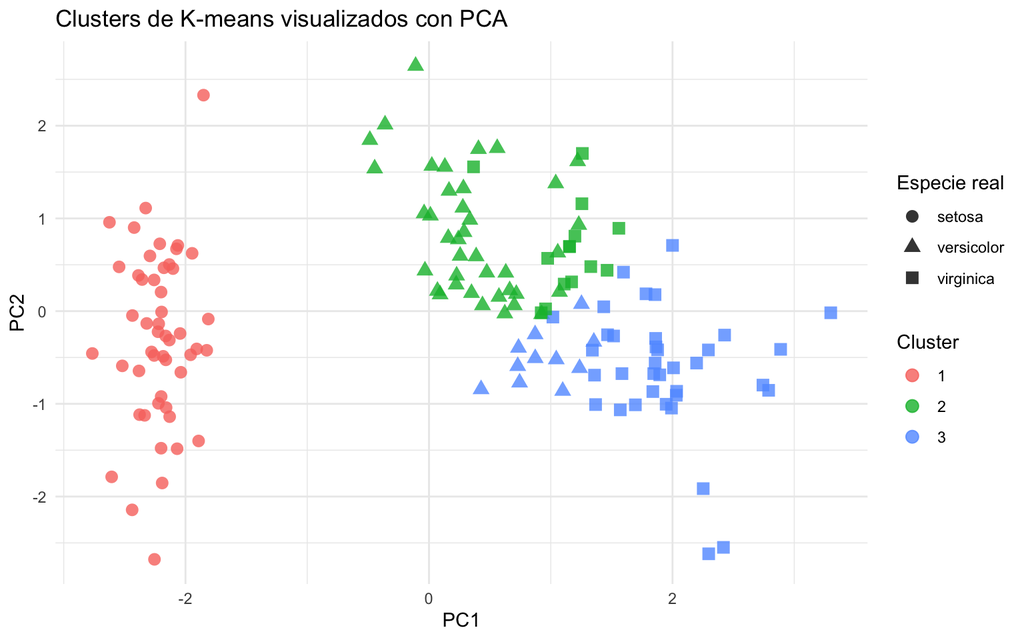

```r
pca_iris <- prcomp(iris_scaled, center = FALSE, scale. = FALSE)

pca_df <- as_tibble(pca_iris$x[, 1:2]) %>%
  mutate(
    cluster_kmeans = iris_km$cluster_kmeans,
    Species = iris$Species
  )

ggplot(pca_df, aes(PC1, PC2, color = cluster_kmeans, shape = Species)) +
  geom_point(size = 3, alpha = 0.8) +
  theme_minimal() +
  labs(
    title = "Clusters de K-means visualizados con PCA",
    color = "Cluster",
    shape = "Especie real"
  )
```

## 7. Comparación exploratoria con la etiqueta real

Aunque `Species` no se usó para entrenar, podemos comparar los clusters obtenidos con la clasificación real.

```r
table(
  Cluster = iris_km$cluster_kmeans,
  Species = iris_km$Species
)
```

```
##        Species
## Cluster setosa versicolor virginica
##       1     50          0         0
##       2      0         39        14
##       3      0         11        36
```

Interpretación esperada:

- Un buen clustering debería mostrar cierta correspondencia con las especies.
- Puede haber mezclas entre especies cercanas en el espacio morfológico.
- La comparación con una etiqueta externa es útil, pero no siempre existe en problemas reales.

# Selección del número de clusters

## 8. Método del codo

El método del codo evalúa la suma de cuadrados dentro de clusters. Buscamos un punto donde agregar más clusters ya no reduzca mucho el error.

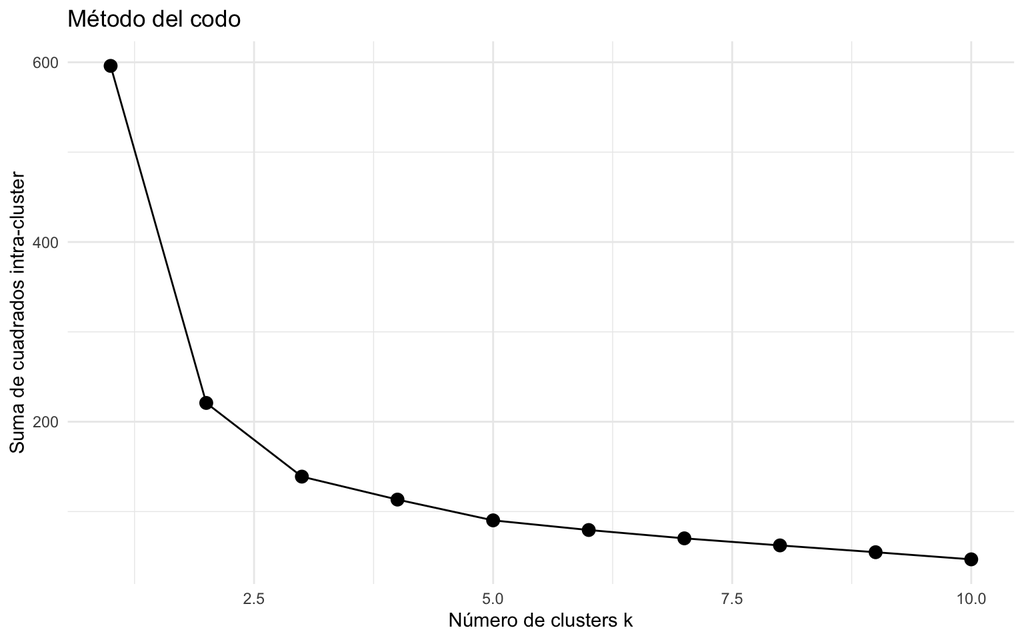

```r
wss <- map_dbl(1:10, function(k) {
  kmeans(iris_scaled, centers = k, nstart = 25)$tot.withinss
})

elbow_df <- tibble(k = 1:10, wss = wss)

ggplot(elbow_df, aes(k, wss)) +
  geom_line() +
  geom_point(size = 3) +
  theme_minimal() +
  labs(
    title = "Método del codo",
    x = "Número de clusters k",
    y = "Suma de cuadrados intra-cluster"
  )
```

## 9. Silhouette

El índice silhouette compara qué tan bien asignada está cada observación a su cluster. Toma valores entre -1 y 1.

- Valores cercanos a 1: observación bien asignada.
- Valores cercanos a 0: observación entre dos clusters.
- Valores negativos: posible mala asignación.

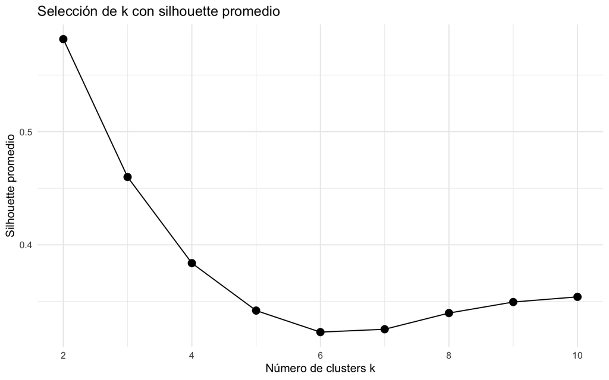

```r
sil_df <- map_dfr(2:10, function(k) {
  km <- kmeans(iris_scaled, centers = k, nstart = 25)
  sil <- silhouette(km$cluster, d_iris)
  tibble(
    k = k,
    avg_silhouette = mean(sil[, "sil_width"])
  )
})

ggplot(sil_df, aes(k, avg_silhouette)) +
  geom_line() +
  geom_point(size = 3) +
  theme_minimal() +
  labs(
    title = "Selección de k con silhouette promedio",
    x = "Número de clusters k",
    y = "Silhouette promedio"
  )
```

```
##   cluster size ave.sil.width
## 1       1   50          0.64
## 2       2   53          0.39
## 3       3   47          0.35
```

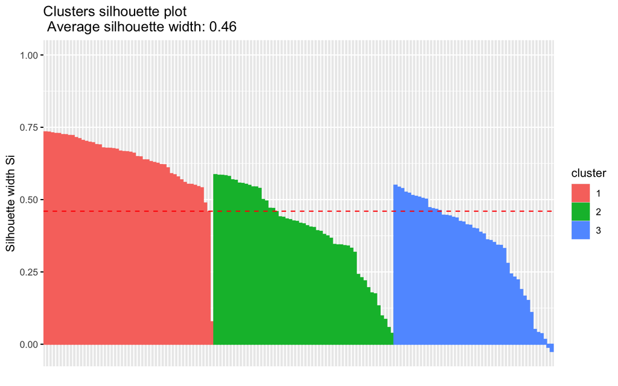

```r
sil_k3 <- silhouette(km3$cluster, d_iris)
fviz_silhouette(sil_k3)
```

# Clustering jerárquico

## 10. Clustering aglomerativo

El clustering jerárquico comienza con cada observación como un cluster separado y va fusionando los grupos más cercanos.

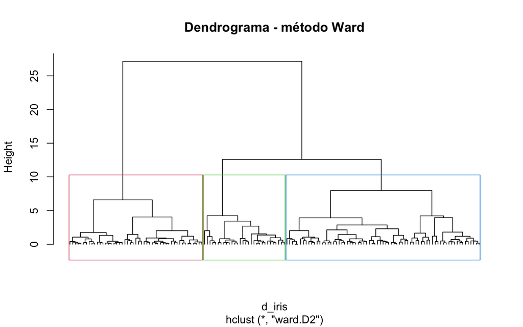

```r
hc_iris <- hclust(d_iris, method = "ward.D2")

plot(hc_iris, labels = FALSE, hang = -1, main = "Dendrograma - método Ward")
rect.hclust(hc_iris, k = 3, border = 2:4)
```

Cortamos el dendrograma en tres grupos.

```r
iris_hc <- iris %>%
  mutate(cluster_hc = factor(cutree(hc_iris, k = 3)))

table(
  Cluster = iris_hc$cluster_hc,
  Species = iris_hc$Species
)
```

```
##        Species
## Cluster setosa versicolor virginica
##       1     49          0         0
##       2      1         27         2
##       3      0         23        48
```

# Distancia de Gower para datos mixtos

Cuando hay variables numéricas y categóricas juntas, la distancia euclidiana no es adecuada directamente. La distancia de **Gower** permite combinar variables de distinto tipo.

## 11. Ejemplo simple con datos mixtos

```r
clientes <- tibble(
  edad = c(22, 25, 31, 45, 48, 52, 60, 63),
  ingreso = c(500, 620, 800, 1500, 1700, 1600, 2300, 2500),
  canal = factor(c("online", "online", "online", "tienda", "tienda", "tienda", "tienda", "tienda")),
  usa_promocion = factor(c("si", "si", "no", "si", "no", "no", "no", "no"))
)

clientes
```

| edad | ingreso | canal | usa_promocion |
| --- | --- | --- | --- |
| 22 | 500 | online | si |
| 25 | 620 | online | si |
| 31 | 800 | online | no |
| 45 | 1500 | tienda | si |
| 48 | 1700 | tienda | no |
| 52 | 1600 | tienda | no |
| 60 | 2300 | tienda | no |
| 63 | 2500 | tienda | no |

```r
d_gower <- daisy(clientes, metric = "gower")

as.matrix(d_gower)[1:5, 1:5]
```

```
##            1          2         3         4         5
## 1 0.00000000 0.03329268 0.3423780 0.5152439 0.8085366
## 2 0.03329268 0.00000000 0.3090854 0.4819512 0.7752439
## 3 0.34237805 0.30908537 0.0000000 0.6728659 0.4661585
## 4 0.51524390 0.48195122 0.6728659 0.0000000 0.2932927
## 5 0.80853659 0.77524390 0.4661585 0.2932927 0.0000000
```

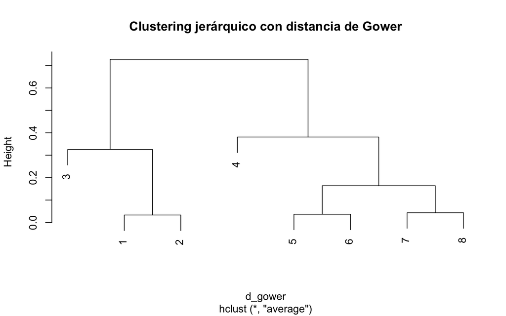

```r
hc_clientes <- hclust(d_gower, method = "average")
plot(hc_clientes, main = "Clustering jerárquico con distancia de Gower")
```

# Interpretación estadística de clusters

Una vez definidos los clusters, podemos preguntarnos qué variables los diferencian.

## 12. Comparación de variables numéricas entre clusters

```r
iris_km %>%
  group_by(cluster_kmeans) %>%
  summarise(
    n = n(),
    across(where(is.numeric), list(media = mean, sd = sd), .names = "{.col}_{.fn}"),
    .groups = "drop"
  )
```

| cluster_kmeans | n | Sepal.Length_media | Sepal.Length_sd | Sepal.Width_media | Sepal.Width_sd | Petal.Length_media | Petal.Length_sd | Petal.Width_media | Petal.Width_sd | n_media | n_sd |
| --- | --- | --- | --- | --- | --- | --- | --- | --- | --- | --- | --- |
| 1 | 50 | 5.006000 | 0.3524897 | 3.428000 | 0.3790644 | 1.462000 | 0.1736640 | 0.246000 | 0.1053856 | 50 | NA |
| 2 | 53 | 5.801887 | 0.4054867 | 2.673585 | 0.2543097 | 4.369811 | 0.5604205 | 1.413208 | 0.3113480 | 53 | NA |
| 3 | 47 | 6.780851 | 0.4906244 | 3.095745 | 0.2620633 | 5.510638 | 0.6380112 | 1.972340 | 0.3308107 | 47 | NA |

```r
anova_sepal <- aov(Sepal.Length ~ cluster_kmeans, data = iris_km)
summary(anova_sepal)
```

```
##                 Df Sum Sq Mean Sq F value Pr(>F)
## cluster_kmeans   2  76.46   38.23   218.6 <2e-16 ***
## Residuals      147  25.71    0.17
## ---
## Signif. codes:  0 '***' 0.001 '**' 0.01 '*' 0.05 '.' 0.1 ' ' 1
```

## 13. Prueba chi-cuadrado entre cluster y etiqueta externa

```r
tab_cluster_species <- table(iris_km$cluster_kmeans, iris_km$Species)
tab_cluster_species
```

```
##
##     setosa versicolor virginica
##   1     50          0         0
##   2      0         39        14
##   3      0         11        36
```

```r
chisq.test(tab_cluster_species)
```

```
##
##  Pearson's Chi-squared test
##
## data:  tab_cluster_species
## X-squared = 187.64, df = 4, p-value < 2.2e-16
```

Interpretación:

- Si el valor-p es bajo, hay asociación entre cluster y especie.
- Esto no prueba que el clustering sea “correcto”, pero indica que los grupos recuperan parte de la estructura biológica conocida.

# Parte II: Análisis de asociación

## 14. Conceptos principales

Una regla de asociación tiene la forma:

$$A \Rightarrow B$$

Donde:

- `A` es el antecedente o lado izquierdo de la regla.
- `B` es el consecuente o lado derecho de la regla.

Métricas clave:

- **Soporte**: proporción de transacciones que contienen `A` y `B`.
- **Confianza**: proporción de transacciones con `A` que también contienen `B`.
- **Lift**: mide si `A` y `B` aparecen juntos más de lo esperado por azar.

Interpretación rápida de `lift`:

- `lift > 1`: asociación positiva.
- `lift = 1`: independencia aproximada.
- `lift < 1`: asociación negativa.

# Datos Groceries

## 15. Cargar transacciones

```r
data("Groceries")

Groceries
```

```
## transactions in sparse format with
##  9835 transactions (rows) and
##  169 items (columns)
```

```r
inspect(Groceries[1:5])
```

```
##     items
## [1] {citrus fruit,
##      semi-finished bread,
##      margarine,
##      ready soups}
## [2] {tropical fruit,
##      yogurt,
##      coffee}
## [3] {whole milk}
## [4] {pip fruit,
##      yogurt,
##      cream cheese ,
##      meat spreads}
## [5] {other vegetables,
##      whole milk,
##      condensed milk,
##      long life bakery product}
```

## 16. Frecuencia de ítems

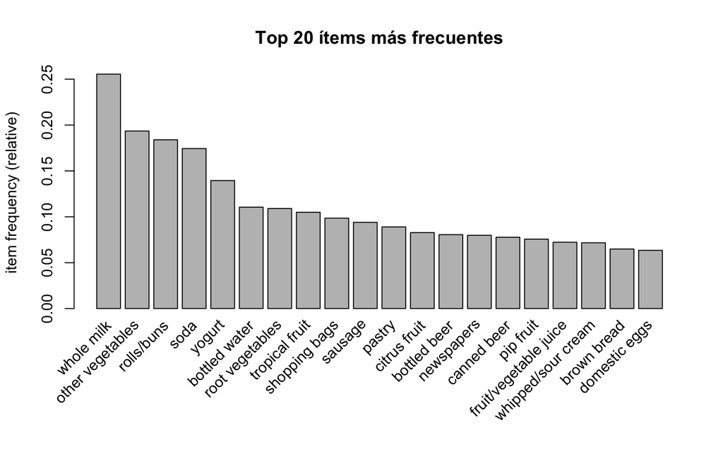

```r
itemFrequencyPlot(
  Groceries,
  topN = 20,
  type = "relative",
  main = "Top 20 ítems más frecuentes"
)
```

## 17. Reglas con Apriori

```r
rules <- apriori(
  Groceries,
  parameter = list(
    supp = 0.001,
    conf = 0.3,
    minlen = 2
  )
)
```

```
## Apriori
##
## Parameter specification:
##  confidence minval smax arem  aval originalSupport maxtime support minlen
##         0.3    0.1    1 none FALSE            TRUE       5   0.001      2
##  maxlen target  ext
##      10  rules TRUE
##
## Algorithmic control:
##  filter tree heap memopt load sort verbose
##     0.1 TRUE TRUE  FALSE TRUE    2    TRUE
##
## Absolute minimum support count: 9
##
## set item appearances ...[0 item(s)] done [0.00s].
## set transactions ...[169 item(s), 9835 transaction(s)] done [0.00s].
## sorting and recoding items ... [157 item(s)] done [0.00s].
## creating transaction tree ... done [0.00s].
## checking subsets of size 1 2 3 4 5 6 done [0.01s].
## writing ... [13770 rule(s)] done [0.00s].
## creating S4 object  ... done [0.00s].
```

```r
rules
```

```
## set of 13770 rules
```

```r
rules_lift <- sort(rules, by = "lift", decreasing = TRUE)
inspect(head(rules_lift, 10))
```

```
##      lhs                                rhs                support
## [1]  {bottled beer, red/blush wine}  => {liquor}           0.001931876
## [2]  {ham, white bread}              => {processed cheese} 0.001931876
## [3]  {bottled beer, liquor}          => {red/blush wine}   0.001931876
## [4]  {Instant food products, soda}   => {hamburger meat}   0.001220132
## [5]  {curd, sugar}                   => {flour}            0.001118454
## [6]  {sugar, baking powder}          => {flour}            0.001016777
## [7]  {processed cheese, white bread} => {ham}              0.001931876
## [8]  {soda, popcorn}                 => {salty snack}      0.001220132
## [9]  {flour, baking powder}          => {sugar}            0.001016777
## [10] {ham, processed cheese}         => {white bread}      0.001931876
##      confidence coverage    lift     count
## [1]  0.3958333  0.004880529 35.71579 19
## [2]  0.3800000  0.005083884 22.92822 19
## [3]  0.4130435  0.004677173 21.49356 19
## [4]  0.6315789  0.001931876 18.99565 12
## [5]  0.3235294  0.003457041 18.60767 11
## [6]  0.3125000  0.003253686 17.97332 10
## [7]  0.4634146  0.004168785 17.80345 19
## [8]  0.6315789  0.001931876 16.69779 12
## [9]  0.5555556  0.001830198 16.40807 10
## [10] 0.6333333  0.003050330 15.04549 19
```

## 18. Filtrado de reglas

En análisis de asociación no basta con generar muchas reglas. Hay que filtrarlas según una pregunta concreta.

Ejemplo: reglas que predicen compra de `whole milk`.

```r
rules_milk <- subset(
  rules,
  rhs %in% "whole milk" &
    lift > 1.2 &
    confidence > 0.3
)

rules_milk <- sort(rules_milk, by = "lift", decreasing = TRUE)
inspect(head(rules_milk, 10))
```

```
##      lhs                      rhs              support confidence    coverage     lift count
## [1]  {rice,
##       sugar}               => {whole milk} 0.001220132          1 0.001220132 3.913649    12
## [2]  {canned fish,
##       hygiene articles}    => {whole milk} 0.001118454          1 0.001118454 3.913649    11
## [3]  {root vegetables,
##       butter,
##       rice}                => {whole milk} 0.001016777          1 0.001016777 3.913649    10
## [4]  {root vegetables,
##       whipped/sour cream,
##       flour}               => {whole milk} 0.001728521          1 0.001728521 3.913649    17
## [5]  {butter,
##       soft cheese,
##       domestic eggs}       => {whole milk} 0.001016777          1 0.001016777 3.913649    10
## [6]  {pip fruit,
##       butter,
##       hygiene articles}    => {whole milk} 0.001016777          1 0.001016777 3.913649    10
## [7]  {root vegetables,
##       whipped/sour cream,
##       hygiene articles}    => {whole milk} 0.001016777          1 0.001016777 3.913649    10
## [8]  {pip fruit,
##       root vegetables,
##       hygiene articles}    => {whole milk} 0.001016777          1 0.001016777 3.913649    10
## [9]  {cream cheese ,
##       domestic eggs,
##       sugar}               => {whole milk} 0.001118454          1 0.001118454 3.913649    11
## [10] {curd,
##       domestic eggs,
##       sugar}               => {whole milk} 0.001016777          1 0.001016777 3.913649    10
```

## 19. Reglas redundantes

Una regla puede ser redundante si entrega información similar a otra regla más general.

```r
is_red <- is.redundant(rules_milk)

table(is_red)
```

```
## is_red
## FALSE  TRUE
##  2891   770
```

```r
rules_milk_pruned <- rules_milk[!is_red]
inspect(head(sort(rules_milk_pruned, by = "lift"), 10))
```

```
##      lhs                      rhs              support confidence    coverage     lift count
## [1]  {rice,
##       sugar}               => {whole milk} 0.001220132          1 0.001220132 3.913649    12
## [2]  {canned fish,
##       hygiene articles}    => {whole milk} 0.001118454          1 0.001118454 3.913649    11
## [3]  {root vegetables,
##       butter,
##       rice}                => {whole milk} 0.001016777          1 0.001016777 3.913649    10
## [4]  {root vegetables,
##       whipped/sour cream,
##       flour}               => {whole milk} 0.001728521          1 0.001728521 3.913649    17
## [5]  {butter,
##       soft cheese,
##       domestic eggs}       => {whole milk} 0.001016777          1 0.001016777 3.913649    10
## [6]  {pip fruit,
##       butter,
##       hygiene articles}    => {whole milk} 0.001016777          1 0.001016777 3.913649    10
## [7]  {root vegetables,
##       whipped/sour cream,
##       hygiene articles}    => {whole milk} 0.001016777          1 0.001016777 3.913649    10
## [8]  {pip fruit,
##       root vegetables,
##       hygiene articles}    => {whole milk} 0.001016777          1 0.001016777 3.913649    10
## [9]  {cream cheese ,
##       domestic eggs,
##       sugar}               => {whole milk} 0.001118454          1 0.001118454 3.913649    11
## [10] {curd,
##       domestic eggs,
##       sugar}               => {whole milk} 0.001016777          1 0.001016777 3.913649    10
```

## 20. Visualización de reglas

```r
# Puede abrir una visualización interactiva dependiendo del entorno.
plot(rules_milk_pruned, method = "graph", engine = "htmlwidget")
```

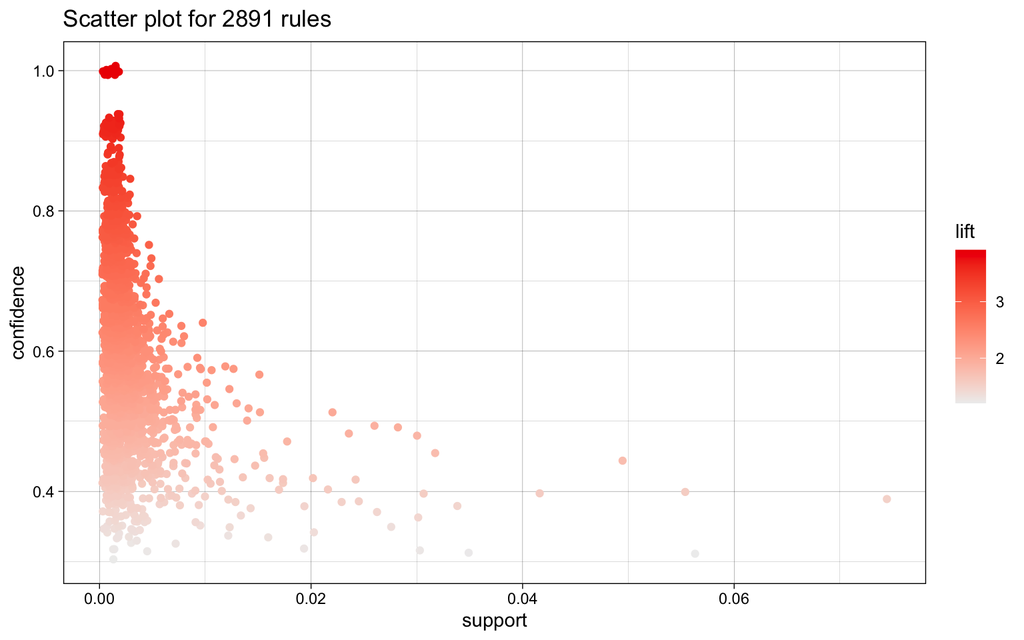

```r
plot(
  rules_milk_pruned,
  measure = c("support", "confidence"),
  shading = "lift"
)
```

# Pruebas estadísticas para una regla específica

## 21. Ejemplo: yogurt => whole milk

Queremos evaluar si la presencia de `yogurt` se asocia estadísticamente con la presencia de `whole milk`.

```r
M <- as(Groceries, "matrix")

X <- M[, "yogurt"]
Y <- M[, "whole milk"]

tab <- table(Yogurt = X, WholeMilk = Y)
tab
```

```
##        WholeMilk
## Yogurt  FALSE TRUE
##   FALSE  6501 1962
##   TRUE    821  551
```

```r
fisher.test(tab)
```

```
##
##  Fisher's Exact Test for Count Data
##
## data:  tab
## p-value < 2.2e-16
## alternative hypothesis: true odds ratio is not equal to 1
## 95 percent confidence interval:
##  1.969687 2.509021
## sample estimates:
## odds ratio
##   2.223571
```

```r
chisq.test(tab)
```

```
##
##  Pearson's Chi-squared test with Yates' continuity correction
##
## data:  tab
## X-squared = 177.99, df = 1, p-value < 2.2e-16
```

Interpretación:

- `fisher.test()` es útil cuando algunas celdas tienen conteos pequeños.
- `chisq.test()` es una aproximación adecuada cuando los conteos esperados son suficientemente grandes.
- Un valor-p bajo sugiere que ambos productos no aparecen juntos de forma independiente.
- El valor-p no reemplaza a soporte, confianza y lift; son perspectivas complementarias.

# Parte III: Integración de clustering y análisis de asociación

## 22. Idea general

Podemos combinar ambos enfoques de la siguiente forma:

1. Crear clusters de observaciones.
2. Convertir variables relevantes en categorías.
3. Agregar el cluster como un ítem más.
4. Minar reglas de asociación que expliquen cada cluster.

Esto permite pasar de un resultado como:

> “El cluster 2 tiene 78 observaciones”

A una interpretación más útil:

> “El cluster 2 se caracteriza por alto ticket promedio, baja sensibilidad a promociones y preferencia por compra presencial”.

# Ejemplo integrado: segmentación de clientes

Simularemos una base de clientes con variables numéricas y categóricas. Luego:

- Aplicaremos clustering con distancia de Gower.
- Describiremos los clusters.
- Usaremos reglas de asociación para interpretar los segmentos.

## 23. Simular datos

```r
set.seed(2026)

n <- 240

clientes_sim <- tibble(
  edad = c(
    rnorm(80, mean = 24, sd = 4),
    rnorm(80, mean = 42, sd = 6),
    rnorm(80, mean = 61, sd = 5)
  ),
  ingreso = c(
    rnorm(80, mean = 650, sd = 120),
    rnorm(80, mean = 1400, sd = 250),
    rnorm(80, mean = 2200, sd = 300)
  ),
  visitas_mes = c(
    rpois(80, lambda = 8),
    rpois(80, lambda = 4),
    rpois(80, lambda = 2)
  ),
  ticket_promedio = c(
    rnorm(80, mean = 25, sd = 7),
    rnorm(80, mean = 55, sd = 12),
    rnorm(80, mean = 90, sd = 15)
  ),
  canal = factor(c(
    sample(c("online", "mixto"), 80, replace = TRUE, prob = c(0.75, 0.25)),
    sample(c("online", "mixto", "tienda"), 80, replace = TRUE, prob = c(0.25, 0.45, 0.30)),
    sample(c("tienda", "mixto"), 80, replace = TRUE, prob = c(0.70, 0.30))
  )),
  categoria_fav = factor(c(
    sample(c("snacks", "bebidas", "tecnologia"), 80, replace = TRUE),
    sample(c("hogar", "tecnologia", "salud"), 80, replace = TRUE),
    sample(c("salud", "hogar"), 80, replace = TRUE)
  )),
  usa_promocion = factor(c(
    sample(c("alta", "media"), 80, replace = TRUE, prob = c(0.75, 0.25)),
    sample(c("media", "baja"), 80, replace = TRUE, prob = c(0.55, 0.45)),
    sample(c("baja", "media"), 80, replace = TRUE, prob = c(0.80, 0.20))
  ))
) %>%
  mutate(
    edad = round(pmax(edad, 18)),
    ingreso = round(pmax(ingreso, 300)),
    ticket_promedio = round(pmax(ticket_promedio, 5), 1)
  )

clientes_sim %>% glimpse()
```

```
## Rows: 240
## Columns: 7
## $ edad            <dbl> 26, 20, 25, 24, 21, 18, 21, 20, 24, 22, 22, 21, 23, 23…
## $ ingreso         <dbl> 682, 663, 793, 738, 649, 647, 667, 522, 798, 585, 614,…
## $ visitas_mes     <int> 10, 9, 11, 5, 7, 11, 5, 5, 14, 7, 13, 10, 11, 12, 10, …
## $ ticket_promedio <dbl> 31.7, 23.8, 25.0, 28.6, 21.8, 23.5, 21.0, 22.5, 17.7, …
## $ canal           <fct> online, online, online, online, mixto, online, online,…
## $ categoria_fav   <fct> snacks, bebidas, tecnologia, snacks, tecnologia, snack…
## $ usa_promocion   <fct> alta, alta, alta, alta, alta, alta, alta, media, media…
```

## 24. Clustering con Gower

Como tenemos variables numéricas y categóricas, usamos distancia de Gower.

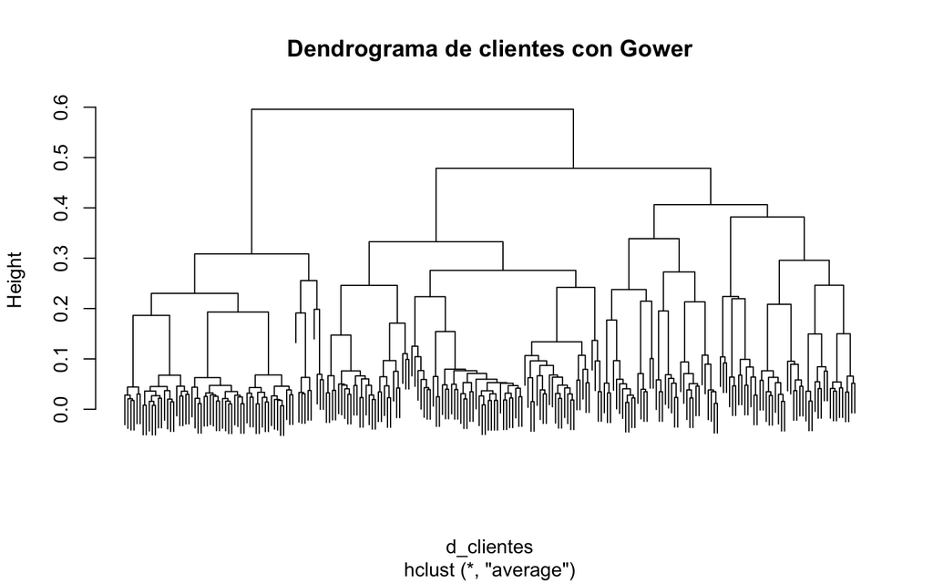

```r
d_clientes <- daisy(clientes_sim, metric = "gower")

hc_clientes_sim <- hclust(d_clientes, method = "average")

plot(hc_clientes_sim, labels = FALSE, main = "Dendrograma de clientes con Gower")
```

## 25. Elegir número de clusters con silhouette

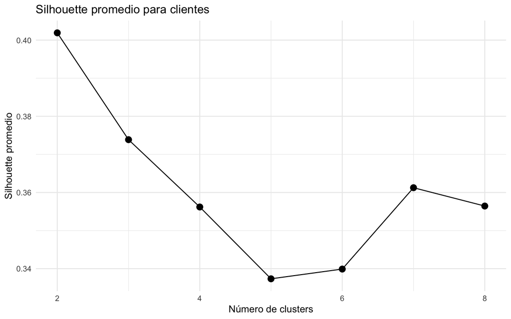

```r
sil_clientes <- map_dfr(2:8, function(k) {
  cl <- cutree(hc_clientes_sim, k = k)
  sil <- silhouette(cl, d_clientes)
  tibble(
    k = k,
    avg_silhouette = mean(sil[, "sil_width"])
  )
})

ggplot(sil_clientes, aes(k, avg_silhouette)) +
  geom_line() +
  geom_point(size = 3) +
  theme_minimal() +
  labs(
    title = "Silhouette promedio para clientes",
    x = "Número de clusters",
    y = "Silhouette promedio"
  )
```

Para este ejemplo usaremos `k = 3`.

```r
clientes_cluster <- clientes_sim %>%
  mutate(cluster = factor(paste0("cluster_", cutree(hc_clientes_sim, k = 3))))

clientes_cluster %>% count(cluster)
```

| cluster | n |
| --- | --- |
| cluster_1 | 66 |
| cluster_2 | 83 |
| cluster_3 | 91 |

## 26. Perfil descriptivo de los clusters

```r
clientes_cluster %>%
  group_by(cluster) %>%
  summarise(
    n = n(),
    edad_media = mean(edad),
    ingreso_medio = mean(ingreso),
    visitas_media = mean(visitas_mes),
    ticket_medio = mean(ticket_promedio),
    .groups = "drop"
  )
```

| cluster | n | edad_media | ingreso_medio | visitas_media | ticket_medio |
| --- | --- | --- | --- | --- | --- |
| cluster_1 | 66 | 23.65152 | 651.0758 | 8.121212 | 23.50909 |
| cluster_2 | 83 | 40.27711 | 1339.1928 | 4.783133 | 53.22651 |
| cluster_3 | 91 | 58.31868 | 2077.4945 | 2.351648 | 83.05165 |

```r
clientes_cluster %>%
  count(cluster, canal) %>%
  group_by(cluster) %>%
  mutate(prop = n / sum(n)) %>%
  arrange(cluster, desc(prop))
```

| cluster | canal | n | prop |
| --- | --- | --- | --- |
| cluster_1 | online | 50 | 0.7575758 |
| cluster_1 | mixto | 16 | 0.2424242 |
| cluster_2 | online | 41 | 0.4939759 |
| cluster_2 | mixto | 33 | 0.3975904 |
| cluster_2 | tienda | 9 | 0.1084337 |
| cluster_3 | tienda | 63 | 0.6923077 |
| cluster_3 | mixto | 28 | 0.3076923 |

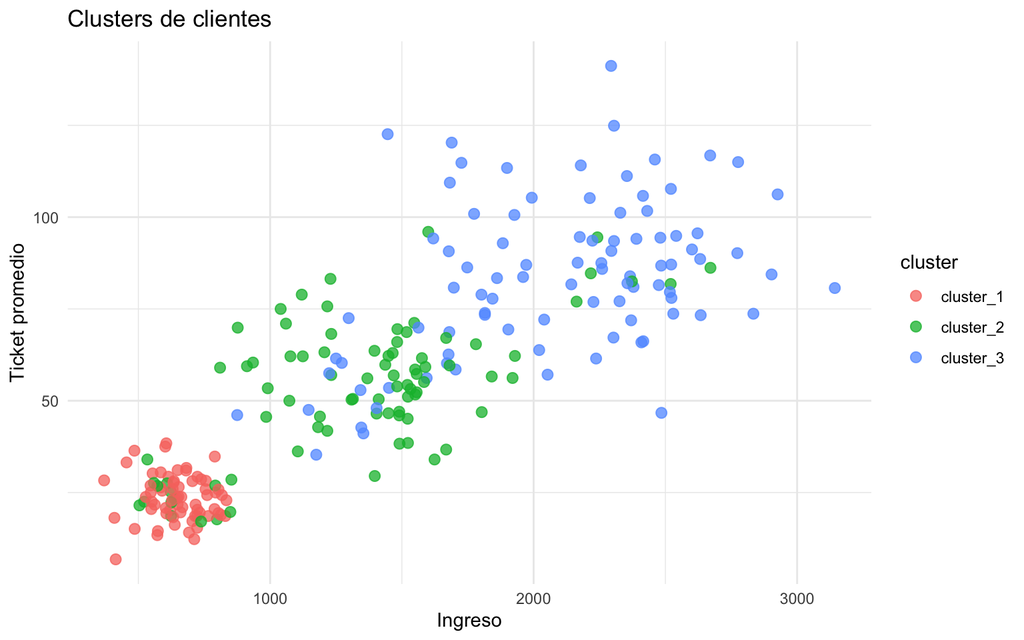

```r
ggplot(clientes_cluster, aes(ingreso, ticket_promedio, color = cluster)) +
  geom_point(alpha = 0.75, size = 2.5) +
  theme_minimal() +
  labs(
    title = "Clusters de clientes",
    x = "Ingreso",
    y = "Ticket promedio"
  )
```

## 27. Convertir variables a transacciones

Para aplicar reglas de asociación, transformamos variables numéricas en categorías.

```r
discretizar_terciles <- function(x) {
  qs <- unique(quantile(x, probs = c(0, 1/3, 2/3, 1), na.rm = TRUE))

  if (length(qs) < 4) {
    cut(x, breaks = 3, labels = c("bajo", "medio", "alto"), include.lowest = TRUE)
  } else {
    cut(x, breaks = qs, labels = c("bajo", "medio", "alto"), include.lowest = TRUE)
  }
}

clientes_disc <- clientes_cluster %>%
  mutate(
    edad = discretizar_terciles(edad),
    ingreso = discretizar_terciles(ingreso),
    visitas_mes = discretizar_terciles(visitas_mes),
    ticket_promedio = discretizar_terciles(ticket_promedio)
  )

head(clientes_disc)
```

| edad | ingreso | visitas_mes | ticket_promedio | canal | categoria_fav | usa_promocion | cluster |
| --- | --- | --- | --- | --- | --- | --- | --- |
| bajo | bajo | alto | bajo | online | snacks | alta | cluster_1 |
| bajo | bajo | alto | bajo | online | bebidas | alta | cluster_1 |
| bajo | bajo | alto | bajo | online | tecnologia | alta | cluster_1 |
| bajo | bajo | medio | bajo | online | snacks | alta | cluster_1 |
| bajo | bajo | alto | bajo | mixto | tecnologia | alta | cluster_1 |
| bajo | bajo | alto | bajo | online | snacks | alta | cluster_1 |

Ahora convertimos el data frame discretizado a formato transaccional.

```r
trans_clientes <- as(clientes_disc, "transactions")

trans_clientes
```

```
## transactions in sparse format with
##  240 transactions (rows) and
##  26 items (columns)
```

```r
inspect(trans_clientes[1:5])
```

```
##     items                       transactionID
## [1] {edad=bajo,
##      ingreso=bajo,
##      visitas_mes=alto,
##      ticket_promedio=bajo,
##      canal=online,
##      categoria_fav=snacks,
##      usa_promocion=alta,
##      cluster=cluster_1}                     1
## [2] {edad=bajo,
##      ingreso=bajo,
##      visitas_mes=alto,
##      ticket_promedio=bajo,
##      canal=online,
##      categoria_fav=bebidas,
##      usa_promocion=alta,
##      cluster=cluster_1}                     2
## [3] {edad=bajo,
##      ingreso=bajo,
##      visitas_mes=alto,
##      ticket_promedio=bajo,
##      canal=online,
##      categoria_fav=tecnologia,
##      usa_promocion=alta,
##      cluster=cluster_1}                     3
## [4] {edad=bajo,
##      ingreso=bajo,
##      visitas_mes=medio,
##      ticket_promedio=bajo,
##      canal=online,
##      categoria_fav=snacks,
##      usa_promocion=alta,
##      cluster=cluster_1}                     4
## [5] {edad=bajo,
##      ingreso=bajo,
##      visitas_mes=alto,
##      ticket_promedio=bajo,
##      canal=mixto,
##      categoria_fav=tecnologia,
##      usa_promocion=alta,
##      cluster=cluster_1}                     5
```

## 28. Reglas para explicar clusters

Buscamos reglas cuyo consecuente sea el cluster. Es decir, queremos reglas del tipo:

$$\text{características del cliente} \Rightarrow \text{cluster}$$

```r
cluster_items <- paste0("cluster=cluster_", 1:3)

rules_clientes <- apriori(
  trans_clientes,
  parameter = list(
    supp = 0.05,
    conf = 0.70,
    minlen = 2,
    maxlen = 5
  ),
  appearance = list(
    rhs = cluster_items,
    default = "lhs"
  )
)
```

```
## Apriori
##
## Parameter specification:
##  confidence minval smax arem  aval originalSupport maxtime support minlen
##         0.7    0.1    1 none FALSE            TRUE       5    0.05      2
##  maxlen target  ext
##       5  rules TRUE
##
## Algorithmic control:
##  filter tree heap memopt load sort verbose
##     0.1 TRUE TRUE  FALSE TRUE    2    TRUE
##
## Absolute minimum support count: 12
##
## set item appearances ...[3 item(s)] done [0.00s].
## set transactions ...[26 item(s), 240 transaction(s)] done [0.00s].
## sorting and recoding items ... [26 item(s)] done [0.00s].
## creating transaction tree ... done [0.00s].
## checking subsets of size 1 2 3 4 5
```

```
##  done [0.00s].
## writing ... [508 rule(s)] done [0.00s].
## creating S4 object  ... done [0.00s].
```

```r
rules_clientes <- sort(rules_clientes, by = "lift", decreasing = TRUE)

rules_clientes
```

```
## set of 508 rules
```

```r
inspect(head(rules_clientes, 15))
```

```
##      lhs                            rhs                    support confidence   coverage     lift count
## [1]  {usa_promocion=alta}        => {cluster=cluster_1} 0.26666667          1 0.26666667 3.636364    64
## [2]  {categoria_fav=snacks,
##       usa_promocion=alta}        => {cluster=cluster_1} 0.08750000          1 0.08750000 3.636364    21
## [3]  {categoria_fav=bebidas,
##       usa_promocion=alta}        => {cluster=cluster_1} 0.08750000          1 0.08750000 3.636364    21
## [4]  {categoria_fav=tecnologia,
##       usa_promocion=alta}        => {cluster=cluster_1} 0.09166667          1 0.09166667 3.636364    22
## [5]  {visitas_mes=alto,
##       usa_promocion=alta}        => {cluster=cluster_1} 0.19166667          1 0.19166667 3.636364    46
## [6]  {visitas_mes=medio,
##       usa_promocion=alta}        => {cluster=cluster_1} 0.07500000          1 0.07500000 3.636364    18
## [7]  {canal=mixto,
##       usa_promocion=alta}        => {cluster=cluster_1} 0.05833333          1 0.05833333 3.636364    14
## [8]  {ticket_promedio=bajo,
##       usa_promocion=alta}        => {cluster=cluster_1} 0.25416667          1 0.25416667 3.636364    61
## [9]  {ingreso=bajo,
##       usa_promocion=alta}        => {cluster=cluster_1} 0.26666667          1 0.26666667 3.636364    64
## [10] {edad=bajo,
##       usa_promocion=alta}        => {cluster=cluster_1} 0.26250000          1 0.26250000 3.636364    63
## [11] {canal=online,
##       usa_promocion=alta}        => {cluster=cluster_1} 0.20833333          1 0.20833333 3.636364    50
## [12] {edad=bajo,
##       canal=mixto}               => {cluster=cluster_1} 0.06250000          1 0.06250000 3.636364    15
## [13] {visitas_mes=alto,
##       categoria_fav=snacks,
##       usa_promocion=alta}        => {cluster=cluster_1} 0.05000000          1 0.05000000 3.636364    12
## [14] {ticket_promedio=bajo,
##       categoria_fav=snacks,
##       usa_promocion=alta}        => {cluster=cluster_1} 0.08333333          1 0.08333333 3.636364    20
## [15] {ingreso=bajo,
##       categoria_fav=snacks,
##       usa_promocion=alta}        => {cluster=cluster_1} 0.08750000          1 0.08750000 3.636364    21
```

## 29. Filtrar reglas por cluster específico

```r
rules_cluster_1 <- subset(rules_clientes, rhs %in% "cluster=cluster_1")
rules_cluster_2 <- subset(rules_clientes, rhs %in% "cluster=cluster_2")
rules_cluster_3 <- subset(rules_clientes, rhs %in% "cluster=cluster_3")

inspect(head(sort(rules_cluster_1, by = "lift"), 5))
```

```
##     lhs                            rhs                    support confidence   coverage     lift count
## [1] {usa_promocion=alta}        => {cluster=cluster_1} 0.26666667          1 0.26666667 3.636364    64
## [2] {categoria_fav=snacks,
##      usa_promocion=alta}        => {cluster=cluster_1} 0.08750000          1 0.08750000 3.636364    21
## [3] {categoria_fav=bebidas,
##      usa_promocion=alta}        => {cluster=cluster_1} 0.08750000          1 0.08750000 3.636364    21
## [4] {categoria_fav=tecnologia,
##      usa_promocion=alta}        => {cluster=cluster_1} 0.09166667          1 0.09166667 3.636364    22
## [5] {visitas_mes=alto,
##      usa_promocion=alta}        => {cluster=cluster_1} 0.19166667          1 0.19166667 3.636364    46
```

```r
inspect(head(sort(rules_cluster_2, by = "lift"), 5))
```

```
##     lhs                            rhs                    support confidence   coverage     lift count
## [1] {categoria_fav=tecnologia,
##      usa_promocion=media}       => {cluster=cluster_2} 0.10833333          1 0.10833333 2.891566    26
## [2] {ingreso=medio,
##      categoria_fav=tecnologia}  => {cluster=cluster_2} 0.11250000          1 0.11250000 2.891566    27
## [3] {edad=medio,
##      categoria_fav=tecnologia}  => {cluster=cluster_2} 0.12500000          1 0.12500000 2.891566    30
## [4] {categoria_fav=tecnologia,
##      usa_promocion=baja}        => {cluster=cluster_2} 0.05416667          1 0.05416667 2.891566    13
## [5] {canal=online,
##      usa_promocion=media}       => {cluster=cluster_2} 0.12083333          1 0.12083333 2.891566    29
```

```r
inspect(head(sort(rules_cluster_3, by = "lift"), 5))
```

```
##     lhs                        rhs                   support confidence  coverage     lift count
## [1] {canal=tienda,
##      categoria_fav=hogar}   => {cluster=cluster_3} 0.1083333          1 0.1083333 2.637363    26
## [2] {canal=tienda,
##      categoria_fav=salud}   => {cluster=cluster_3} 0.1541667          1 0.1541667 2.637363    37
## [3] {ingreso=alto,
##      canal=tienda}          => {cluster=cluster_3} 0.2125000          1 0.2125000 2.637363    51
## [4] {ticket_promedio=alto,
##      canal=tienda,
##      categoria_fav=hogar}   => {cluster=cluster_3} 0.0750000          1 0.0750000 2.637363    18
## [5] {edad=alto,
##      canal=tienda,
##      categoria_fav=hogar}   => {cluster=cluster_3} 0.0625000          1 0.0625000 2.637363    15
```

## 30. Interpretación del ejemplo integrado

Las reglas permiten transformar clusters en descripciones interpretables. Por ejemplo, una regla como:

```
{ingreso=alto, ticket_promedio=alto, canal=tienda} => {cluster=cluster_3}
```

se interpretaría así:

> Los clientes con ingreso alto, ticket promedio alto y preferencia por tienda tienen alta probabilidad de pertenecer al cluster 3.

Lectura de métricas:

- **Soporte**: qué proporción total de clientes cumple la regla completa.
- **Confianza**: de los clientes con esas características, qué proporción cae en ese cluster.
- **Lift**: cuánto más frecuente es ese cluster bajo esas características comparado con lo esperado globalmente.

## 31. Visualización de reglas integradas

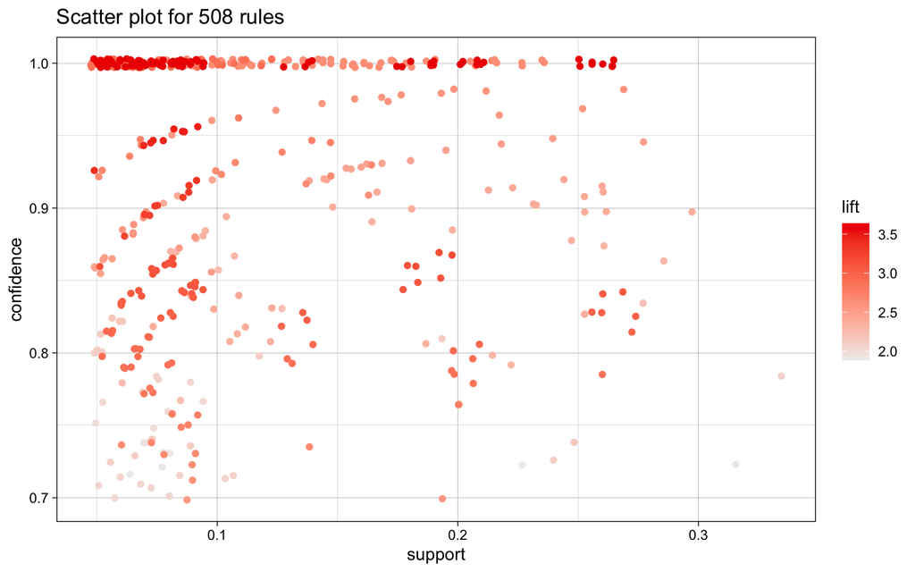

```r
plot(
  rules_clientes,
  measure = c("support", "confidence"),
  shading = "lift"
)
```

```r
plot(
  rules_clientes[1:min(20, length(rules_clientes))],
  method = "graph",
  engine = "htmlwidget"
)
```

# Parte IV: Errores comunes y buenas prácticas

## 32. En clustering

Errores frecuentes:

- Aplicar K-means sin estandarizar variables.
- Elegir `k` sin justificarlo.
- Interpretar clusters solo por visualización 2D.
- Mezclar variables numéricas y categóricas con distancia euclidiana sin procesamiento.
- Concluir causalidad a partir de clusters.

Buenas prácticas:

- Probar más de un método.
- Evaluar estabilidad de clusters.
- Usar silhouette, codo y criterio del dominio.
- Describir clusters con tablas y gráficos.
- Validar con variables externas cuando existan.

## 33. En reglas de asociación

Errores frecuentes:

- Quedarse con miles de reglas sin filtrar.
- Ordenar solo por confianza e ignorar soporte y lift.
- Usar soportes demasiado bajos y obtener reglas raras.
- Interpretar reglas como causalidad.
- No revisar reglas redundantes.

Buenas prácticas:

- Definir una pregunta antes de minar reglas.
- Filtrar por consecuentes relevantes.
- Revisar soporte, confianza y lift simultáneamente.
- Eliminar reglas redundantes.
- Validar reglas con conocimiento del dominio o pruebas estadísticas simples.

# Parte V: Ejercicios propuestos

## Ejercicio 1: Clustering con `mtcars`

Usa el dataset `mtcars` para realizar un análisis de clustering.

Tareas:

1. Selecciona variables numéricas relevantes.
2. Estandariza los datos.
3. Aplica K-means para `k = 2, 3, 4, 5`.
4. Usa método del codo y silhouette para proponer un valor de `k`.
5. Visualiza los clusters usando PCA.
6. Interpreta los clusters usando variables como `mpg`, `wt`, `hp` y `cyl`.

Código inicial:

```r
data(mtcars)

mtcars_df <- mtcars %>%
  rownames_to_column("modelo")

# 1. Seleccionar variables
# 2. Escalar
# 3. Probar distintos k
# 4. Visualizar con PCA
# 5. Interpretar
```

## Ejercicio 2: Clustering jerárquico y distancia de Gower

Construye una base simulada con pacientes que tenga:

- Edad.
- IMC.
- Sexo.
- Grupo clínico.
- Presencia/ausencia de una condición.

Tareas:

1. Calcula distancia de Gower.
2. Aplica clustering jerárquico.
3. Evalúa `k = 2` a `k = 6` con silhouette.
4. Describe los clusters obtenidos.
5. Evalúa si hay asociación entre cluster y grupo clínico usando chi-cuadrado.

Código inicial:

```r
set.seed(101)

pacientes <- tibble(
  edad = round(rnorm(120, 55, 12)),
  imc = round(rnorm(120, 27, 4), 1),
  sexo = factor(sample(c("F", "M"), 120, replace = TRUE)),
  grupo_clinico = factor(sample(c("control", "leve", "severo"), 120, replace = TRUE)),
  condicion = factor(sample(c("si", "no"), 120, replace = TRUE))
)

# Calcular Gower
# Hacer clustering jerárquico
# Evaluar silhouette
# Interpretar clusters
```

## Ejercicio 3: Reglas de asociación con `Groceries`

Usa el dataset `Groceries`.

Tareas:

1. Genera reglas con distintos valores de soporte y confianza.
2. Compara cuántas reglas se obtienen en cada configuración.
3. Filtra reglas que tengan `whole milk` como consecuente.
4. Ordena por lift.
5. Elimina reglas redundantes.
6. Interpreta las cinco reglas más relevantes.

Código inicial:

```r
data("Groceries")

rules_groc <- apriori(
  Groceries,
  parameter = list(supp = 0.002, conf = 0.4, minlen = 2)
)

# Filtrar por rhs = "whole milk"
# Ordenar por lift
# Eliminar redundantes
# Interpretar
```

## Ejercicio 4: Prueba estadística de una regla

Selecciona una regla de asociación de `Groceries`, por ejemplo:

```
{butter} => {whole milk}
```

Tareas:

1. Construye una tabla 2x2 con presencia/ausencia de ambos productos.
2. Aplica `fisher.test()`.
3. Aplica `chisq.test()`.
4. Compara el valor-p con lift, soporte y confianza de la regla.
5. Explica por qué valor-p y lift responden preguntas distintas.

Código inicial:

```r
M <- as(Groceries, "matrix")

X <- M[, "butter"]
Y <- M[, "whole milk"]

tab <- table(Butter = X, WholeMilk = Y)

fisher.test(tab)
chisq.test(tab)
```

## Ejercicio 5: Integración clustering + reglas de asociación

Usa el ejemplo de `clientes_sim` o crea una base propia.

Tareas:

1. Genera clusters usando variables numéricas y categóricas.
2. Selecciona el número de clusters con silhouette.
3. Discretiza variables numéricas.
4. Convierte la tabla a transacciones.
5. Mina reglas del tipo `características => cluster`.
6. Interpreta al menos tres reglas por cluster.
7. Discute si las reglas ayudan a explicar mejor los clusters que las tablas descriptivas.

Código inicial:

```r
# Puedes reutilizar clientes_sim del notebook.

# 1. Calcular distancia de Gower
# 2. Clustering jerárquico
# 3. Cortar en k clusters
# 4. Discretizar variables numéricas
# 5. Convertir a transactions
# 6. Aplicar apriori con rhs = cluster
# 7. Interpretar reglas
```

# Preguntas de repaso conceptual

1. ¿Por qué es importante estandarizar antes de usar K-means?
2. ¿Qué diferencia hay entre K-means y clustering jerárquico?
3. ¿Cuándo usarías distancia de Gower?
4. ¿Qué significa un silhouette negativo?
5. ¿Por qué una regla con alta confianza no necesariamente es interesante?
6. ¿Qué significa `lift > 1`?
7. ¿Por qué no debemos interpretar una regla de asociación como causalidad?
8. ¿Cómo puede ayudar el análisis de asociación a interpretar clusters?
9. ¿Qué diferencia hay entre evaluar clusters con silhouette y evaluarlos con una variable externa?
10. En un dataset biomédico, ¿qué precauciones tomarías antes de interpretar clusters como subtipos biológicos?